# Game Market

12/12/2017

## Introduction

A video game is an electronic game that involves interaction with a user interface to generate visual feedback on a video device such as a TV screen or computer monitor. Recently, Newzoo released the latest quarterly update of its Global Games Market Report. It shows that 2.2 billion gamers across the globe are expected to generate $108.9 billion in game revenues in 2017. In this report, we will review the video game market through datasets provides by Metacritic.com and live topic-related text data from Twitter.com.

| Name | Platform | Genre | Publisher | Global_Sales |
| --- | --- | --- | --- | --- |
| Wii Sports | Wii | Sports | Nintendo | 82.53 |
| Super Mario Bros. | NES | Platform | Nintendo | 40.24 |
| Mario Kart Wii | Wii | Racing | Nintendo | 35.52 |
| Wii Sports Resort | Wii | Sports | Nintendo | 32.77 |
| Pokemon Red/Pokemon Blue | GB | Role-Playing | Nintendo | 31.37 |
| Tetris | GB | Puzzle | Nintendo | 30.26 |
| New Super Mario Bros. | DS | Platform | Nintendo | 29.80 |
| Wii Play | Wii | Misc | Nintendo | 28.92 |
| New Super Mario Bros. Wii | Wii | Platform | Nintendo | 28.32 |
| Duck Hunt | NES | Shooter | Nintendo | 28.31 |

## Video Game Publisher

Through 1980 to 2016, the top 10 publishers for overall sales video game are list in the following table.

| Publisher | Total.Sales | Avg.Sales |
| --- | --- | --- |
| Nintendo | 1788.81 | 2.5337252 |
| Electronic Arts | 1116.96 | 0.8237168 |
| Activision | 731.16 | 0.7422944 |
| Sony Computer Entertainment | 606.48 | 0.8827948 |
| Ubisoft | 471.61 | 0.5054770 |
| Take-Two Interactive | 403.82 | 0.9569194 |
| THQ | 338.44 | 0.4733427 |
| Konami Digital Entertainment | 282.39 | 0.3385971 |
| Sega | 270.35 | 0.4237461 |
| Namco Bandai Games | 254.62 | 0.2711608 |

## Video Game Genre

Video game genres are used to categorize video games based on their gameplay interaction rather than visual or narrative differences.Unlike individual game, each game genre has some game developer.

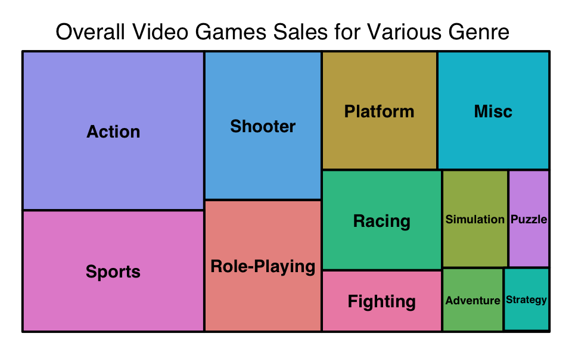

## Video Game Platform

The electronic systems used to play video games are known as platforms. With the development of the game design, the graphic, sound, control technologies are changing in a short period in order to provides the best game service to the customers.

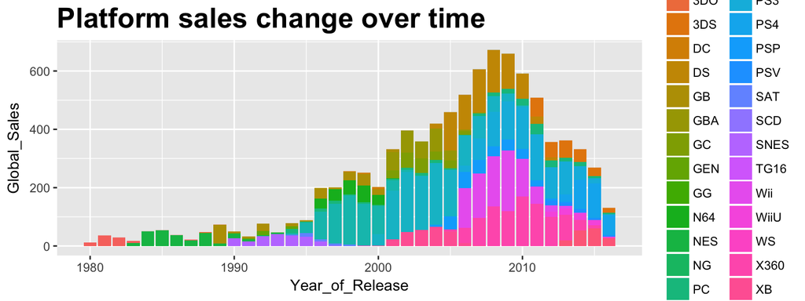

## Word Cloud

[interactive chart not shown]

## Cloud Text

From the word cloud we could see that postive word such as happy, birthday are mentioned a lot in the tweet text. The former company CEO Satoru Iwata was also appeared pretty frequent. It seems Nintendo brought many postive attitude with customers.

## Sentiment Analysis

In order to evaluate customers' tweet attitude, sten sentiment test is applied in the following. Postive word such as thank, super, and happy are used quite often in tweets. And most of the negative words for example wild, crushing, and smash are usually part of the video game material. In general, people from twitter have a strong postive attituide related to Nintendo.

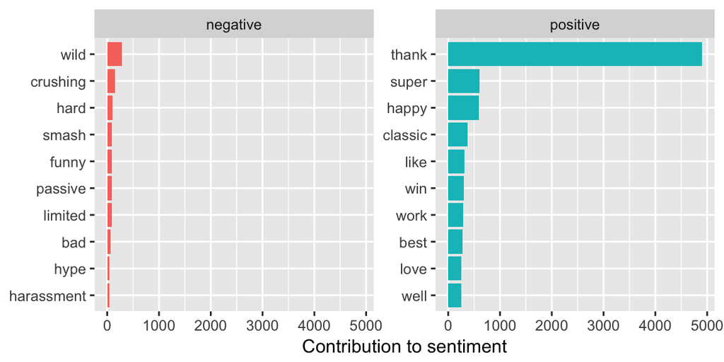

## R Shiny

For user interact plot, please visit the rshiny page http://127.0.0.1:7533/